# AH Statistics Prelim Topic Revision - Web Version

[Click here](https://www.sqa.org.uk/files_ccc/ah-statistics-data-booklet.pdf) to open the Data Booklet.

## 1 Exploratory Data Analysis

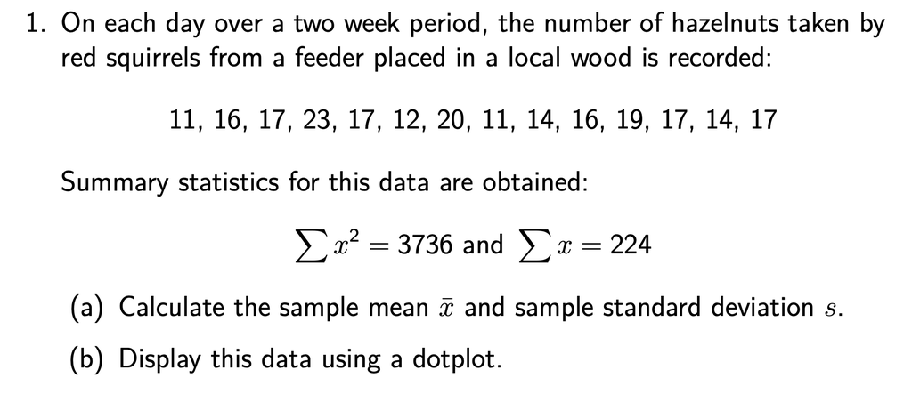

The data booklet contains a formula for calculating $S_{xx}$ using the sums given, and a formula for calculating $s$ from $S_{xx}$ and the sample size.

1. $\bar{x}=\text{16}$ and $s=\text{3.42}$
2. Dotplot with x-axis labelled as "number of hazelnuts".

[figure not shown]

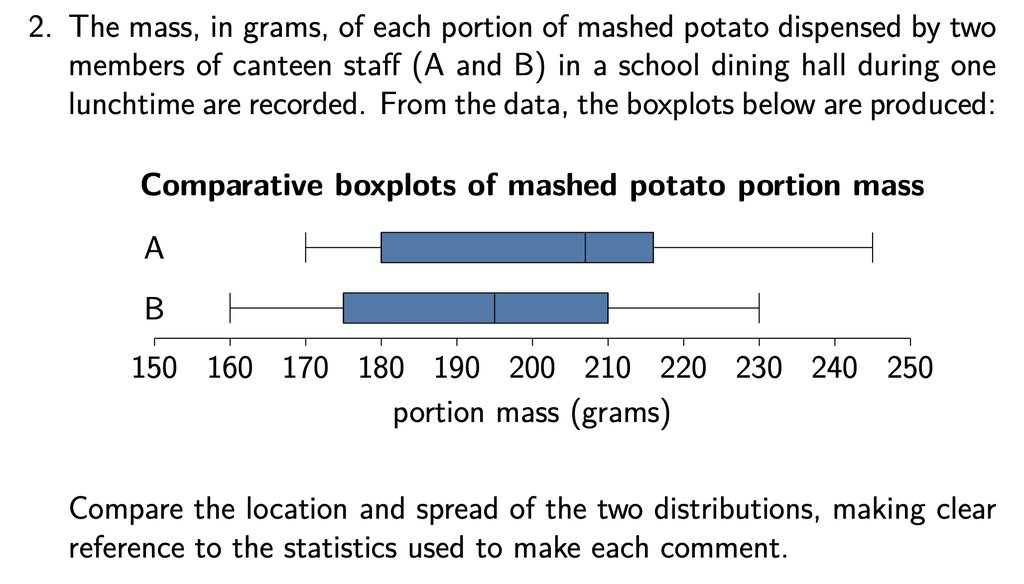

Make sure each comment references the *context* (mass of a portion). Do not be afraid to comment that one or more measure is *broadly similar* - if there is no clear difference, say so!

On average staff member A gave a higher mass of mashed potato per portion, since the median mass was higher.

The consistency of portion mass between the two canteen staff was similar, since the boxplots show similar interquartile ranges.

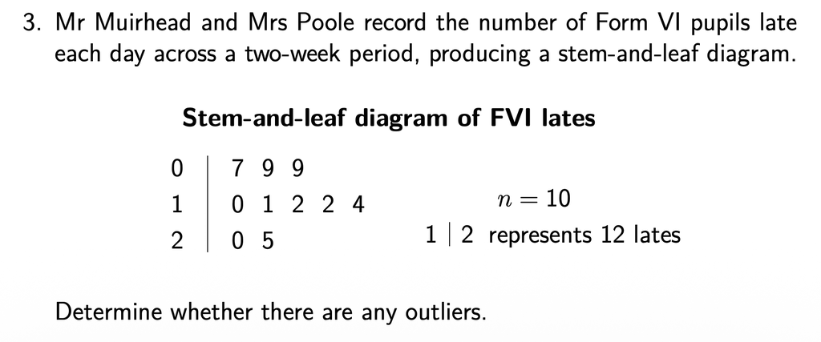

Make sure you learn how to calculate the *upper fence* and the *lower fence* from a set of values, and make a numerical comparison when making a conclusion.

Lower fence = 1.5 and upper fence = 21.5.Since $\text{25}>\text{21.5}$ the value of 25 is an outlier.

[figure not shown]

## 2 Probability Theory I

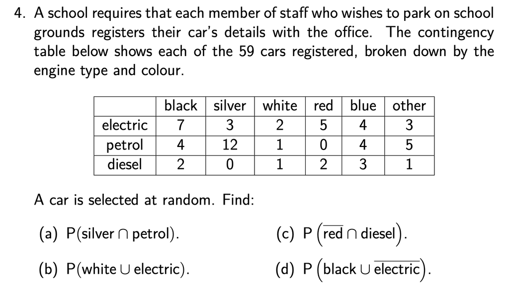

$\cap$ (the *intersection*) means that *both conditions must apply*.

$\cup$ (the *union*) means that *at least one condition must apply*.

$\bar{A}$ means **not** $A$.

1. $\text{P}(\text{silver}\cap\text{petrol})=\dfrac{\text{12}}{\text{59}}$
2. $\text{P}(\text{white}\cup\text{electric})=\dfrac{\text{26}}{\text{59}}$
3. $\text{P}\left(\overline{\text{red}}\cap\text{diesel}\right)=\dfrac{\text{7}}{\text{59}}$.
4. $\text{P}\left(\text{black}\cup\overline{\text{electric}}\right)=\dfrac{\text{42}}{\text{59}}$.

[figure not shown]

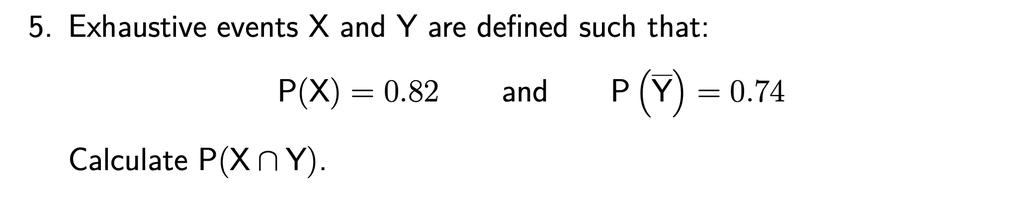

Make sure you memorise the *addition rule* for probability:

$\text{P}(A\cup B)=\text{P}(A)+\text{P}(B)-\text{P}(A\cap B)$

What does *'exhaustive'* tell us?

$\text{P}(\text{X}\cap \text{Y})=\text{0.08}$

[figure not shown]

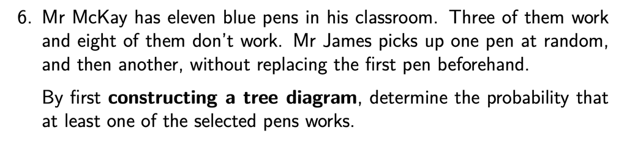

Once one of the 11 pens has been selected, it is *not replaced* before the second is selected. This means there are only 10 pens available to select the next time.

$\text{P}(\text{at least one pen works})=\dfrac{\text{27}}{\text{55}}$ or 0.4909

[figure not shown]

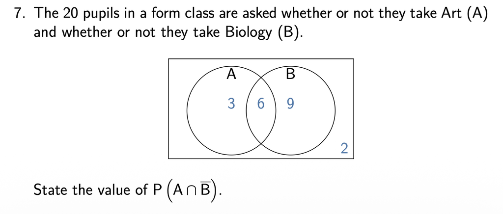

Identify the parts of the Venn diagram which **are in A** and, separately, the parts of the diagram which are **not in B**.

Which part lies in the *intersection* of those conditions?

$\text{P}(\text{A}\cap\overline{\text{B}})=\dfrac{\text{3}}{\text{20}}$ or 0.15

[figure not shown]

## 3 Sampling Theory

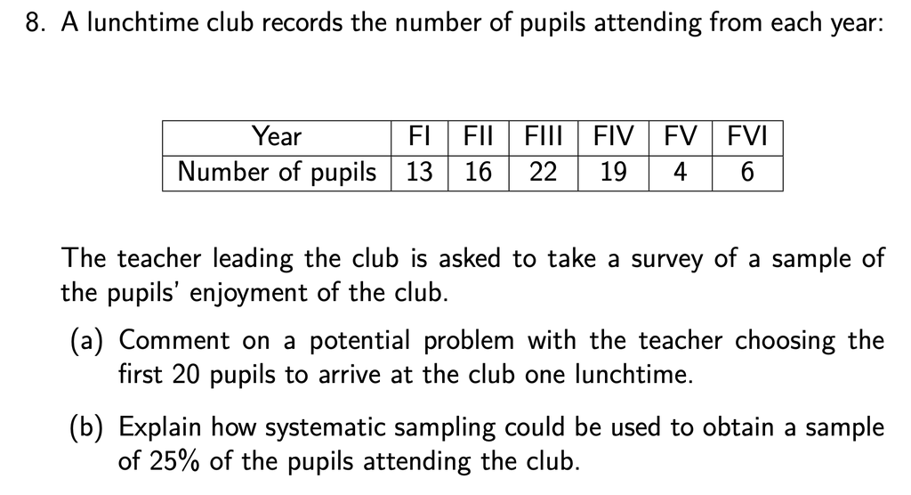

When describing sampling methods, be *very clear* on each step needed.

If you start on pupil 54, for example, and sample every 4, what will you do when you do after reaching pupil number 78?

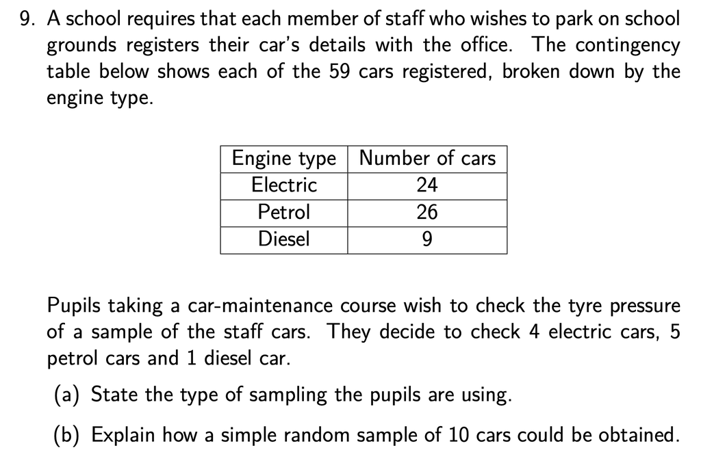

Since *simple random sample* is so... simple... take the time to be more explicit with the steps that might not be covered in detail for other random sampling methods.

1. Quota sampling.
2. Obtain a numbered list of the cars. Select ten different random numbers from 1 to 59 using a random number generator, and then choose the ten cars corresponding to those numbers to make the sample of cars to be checked.

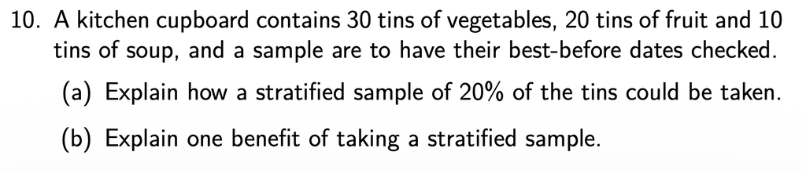

If enough information is given to work out the *number sampled* for each stratum, do so!

1. Make a numbered list of tins for each category. Use a random number generator to select 6 tins of vegetables, 4 tins of fruit and 2 tins of soup. Together, these make a stratified sample of 20% of the tins.
2. Stratified samples tend to be more representative of the populations they are taken from, as they include proportional amounts from each stratum.

## 4 Probability Theory II

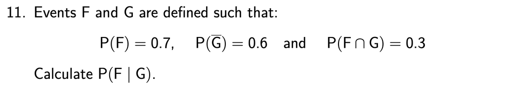

Remember to learn the formula for *conditional probability*:

$\text{P}(A\mid B)=\dfrac{\text{P}(A\cap B)}{\text{P}(B)}$

$\text{P}(\text{F}\mid \text{G})=\frac{3}{4}$ or 0.75

[figure not shown]

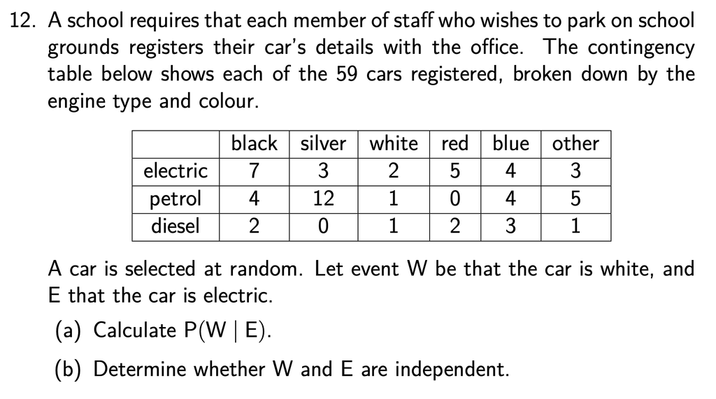

1. It is typically simpler to obtain the numerator and denominator for the conditional probabiity direction *from the table*, rather that using the formula.
2. Events $A$ and $B$ are independent if $\text{P}(A\mid B)=A$.
1. $\text{P}(\text{W}\mid \text{E})=\frac{\text{1}}{\text{12}}$
2. $\text{P}(\text{W})=\frac{\text{4}}{\text{59}}$. Since $\text{P}(\text{W})\ne\text{P}(\text{W}\mid \text{E})$, W and E not independent.

[figure not shown]

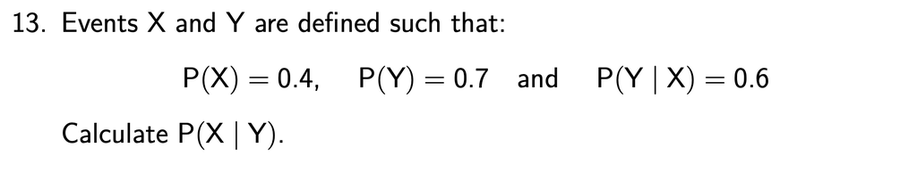

When given a condition such as $\text{P}(B\mid A)$ and you want $\text{P}(A\mid B)$, you can either:

- use a two step method to use the regular conditional probability formula, or...
- use Bayes' Theorem $\text{P}(A\mid B)=\dfrac{\text{P}(B\mid A)\times \text{P}(A)}{\text{P}(B)}$

$\text{P}(\text{X}\mid \text{Y})=\text{0.3429}$

[figure not shown]

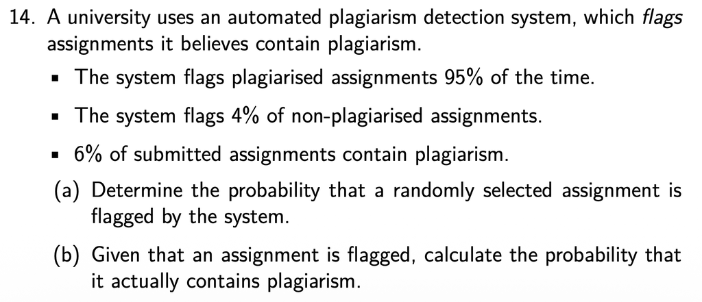

Construct a tree diagram!

You are ultimately looking to find $\text{P}(\text{plagiarism}\mid\text{flagged})$.

1. 0.0946
2. 0.6025

[figure not shown]

## 5 Linear Regression I

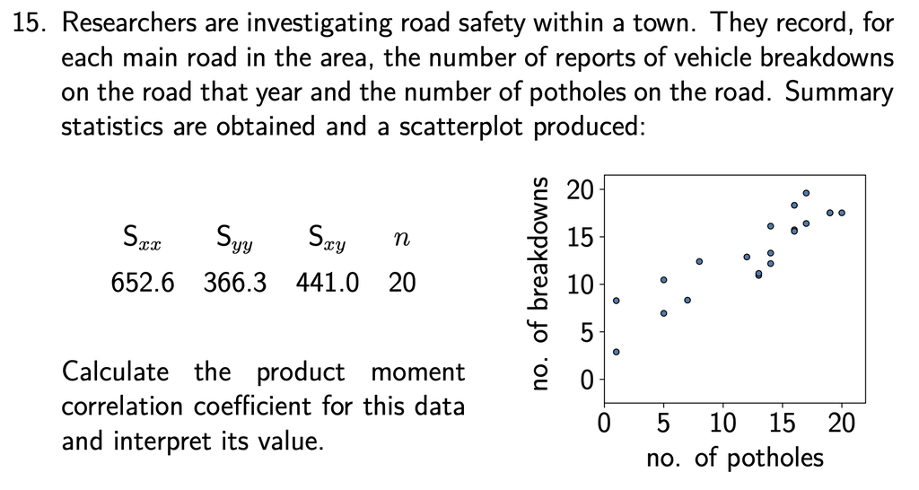

The data booklet contains the formula for the correlation coefficient, $r$.

Take care to not miss out any key words in your conclusion.

The value of $r=0.902$ suggests that there is a strong, positive linear relationship between the number of potholes and the number of breakdowns.

[figure not shown]

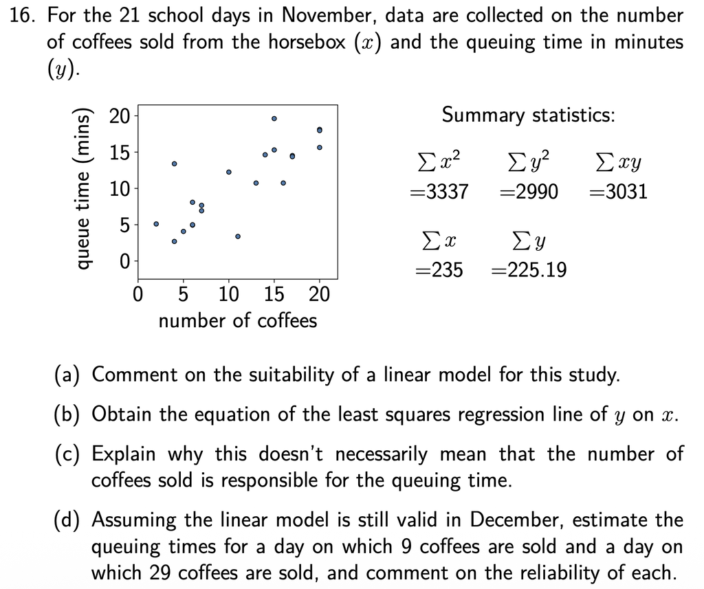

Formula for calculating $a$ and $b$ are in the data booklet, leading to the regression line:

$\hat{y}=a+bx$

1. Since the scatterplot appears to show a positive linear relationship between the number of coffees sold and queuing time, a linear model seems suitable.
2. $\hat{y}=2.638+0.723x$
3. Correlation is not causation. Just because there may be a linear relationship between coffees sold and queuing time does not mean that the number of coffees being sold is causing the queue to be longer or shorter.
4. For 9 coffees sold the predicted queue time is 9.14 minutes, and for 29 coffees sold the predicted queue time is 23.59 minutes. The estimate for 9 coffees is interpolation, which tends to be more reliable than the extrapolation used for the estimate for 29 coffees.

[figure not shown]

## 6 Random Variables

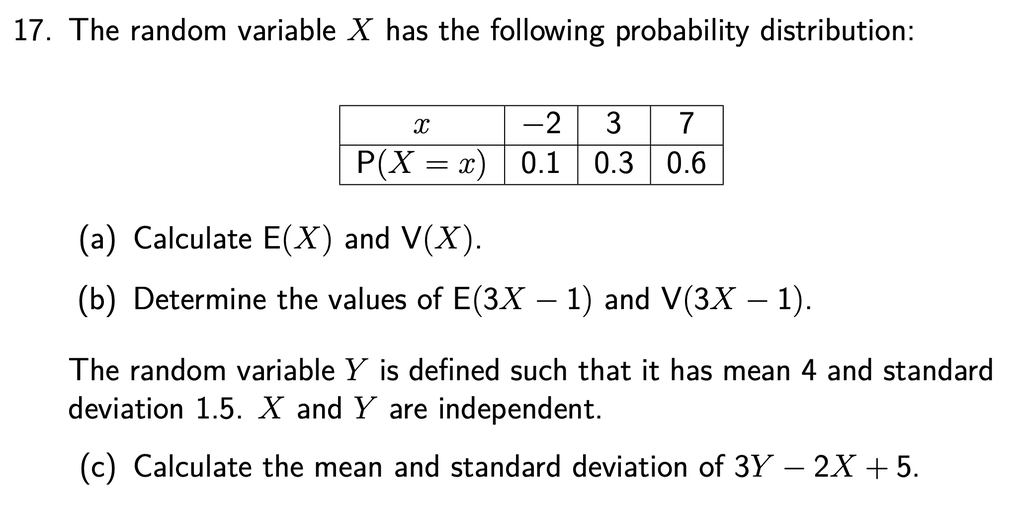

Remember that $\text{E}(X^2)$ and $\text{V}(X)$ are different things!

The following laws needs to be learned:

$\text{E}(aX+b)=a \text{E}(X)+b$

$\text{V}(aX+b)=a^2 \text{V}(X)$

1. $\text{E}(X)=\text{4.9}$ and $\text{V}(X)=\text{8.49}$.
2. $\text{E}(\text{3}X-\text{1})=\text{13.7}$ and $\text{V}(\text{3}X-\text{1})=\text{76.41}$.
3. $\text{E}(\text{3}Y-\text{2}X+\text{5})=\text{7.2}$ and $\text{SD}(\text{3}Y-\text{2}X+\text{5})=\text{7.36}$.

[figure not shown]

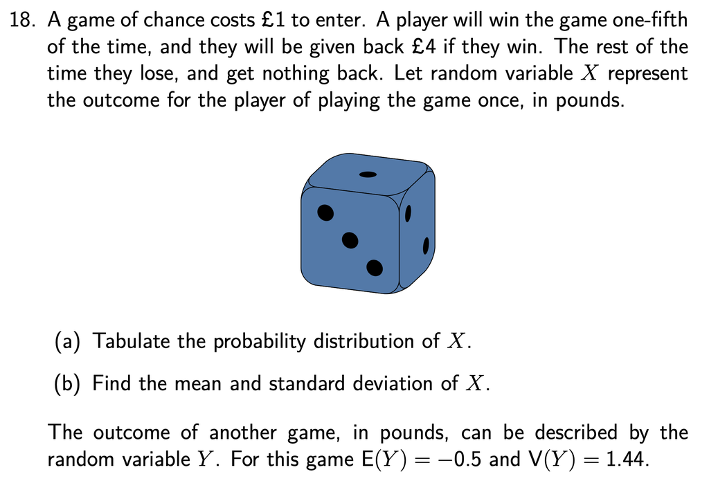

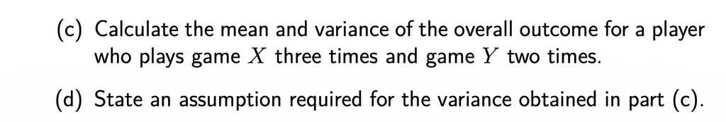

Remember never to described the sum of **independent** observations of $X$ as, for example, $3X$.

Instead, three independent observations would be $X_1+X_2+X_3$.

| $x$ | -1 | 3 |
| --- | --- | --- |
| $\text{P}(X=x)$ | 0.8 | 0.2 |

2. $\text{E}(X)=-\text{0.2}$ and $\text{SD}(X)=\text{1.6}$.
3. Let r.v. $T$ represent the total outcome:

$T=X_\text{1}+X_\text{2}+X_\text{3}+Y_\text{1}+Y_\text{2}$.

$\text{E}(T)=-\text{1.6}$ and $\text{V}(T)=\text{10.56}$.

4. Assume that the outcomes of game $X$ and game $Y$ are independent.

[figure not shown]

## 7 Discrete Distributions

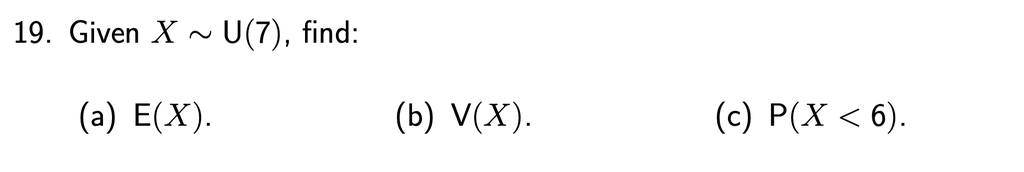

Since there is only a **single parameter**, this is a **discrete** uniform distribution $U(k)$.

Make sure you use the correct formulae for the mean and variance.

No calculator functions are available (or needed) for uniform distributions!

1. $\text{E}(X)=\text{4}$
2. $\text{V}(X)=\text{4}$
3. $\text{P}(X<\text{6})=\frac{\text{5}}{\text{7}}$

[figure not shown]

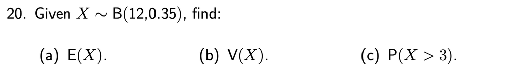

**Equals** binomial probability -> **Bpd**

**Less than or equal to** binomial probability -> **Bcd**

1. $\text{E}(X)=\text{4.2}$
2. $\text{V}(X)=\text{2.73}$
3. $\text{P}(X>\text{3})=\text{0.6534}$

[figure not shown]

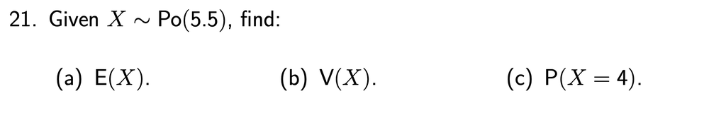

**Equals** Poisson probability -> **Ppd**

**Less than or equal to** Poisson probability -> **Pcd**

1. $\text{E}(X)=\text{5.5}$
2. $\text{V}(X)=\text{5.5}$
3. $\text{P}(X=\text{4})=\text{0.1558}$

[figure not shown]

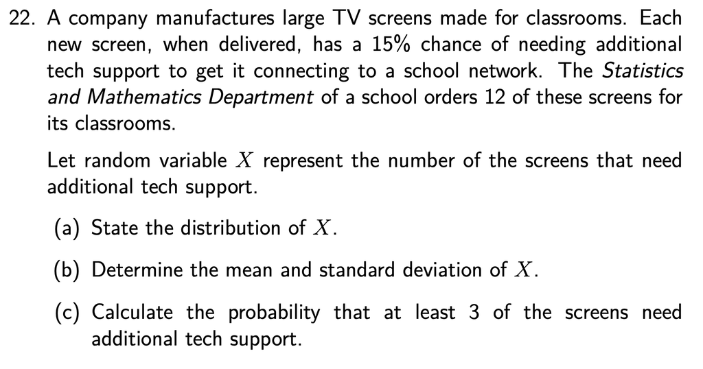

Recognising a distribution from a description is an important skill.

Here, there are 12 *trials* (screens purchased), *each* has the same probability of *success* (needing tech support), and we are interested in the number of *successes* from the 12.

1. $X\sim \text{B}\left(12,0.15\right)$
2. Mean of $X$ is 1.8 and standard deviation of $X$ is 1.237.
3. $\text{P}(X\geqslant 3)=\text{0.2642}$

[figure not shown]

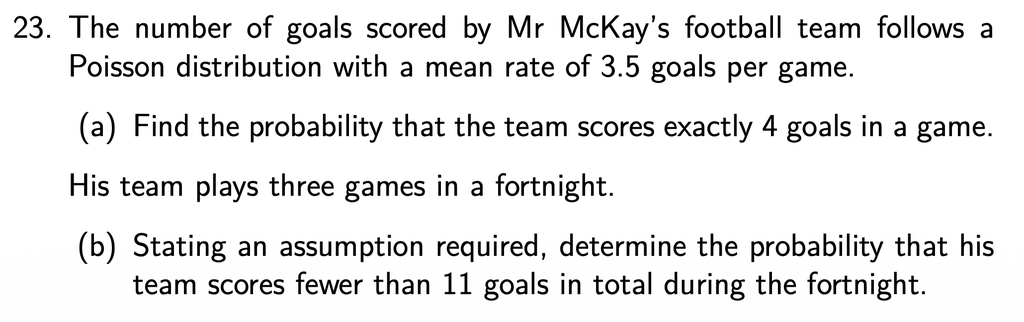

Even if the word "Poisson" wasn't included, the phrase *mean rate* hints at Poisson.

Poisson distributions (provided the *assumption* from part (b) is met) combine nicely.

1. $\text{P}(X= 4)=\text{0.1888}$
2. $\text{P}(Y<11)=\text{0.5207}$

[figure not shown]

## 8 Continuous Distributions

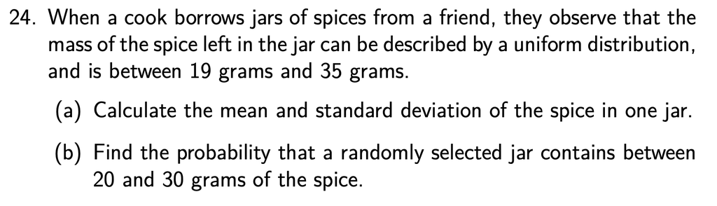

Take care once a *uniform* distribution is needed - is it *discrete* or *continuous*?

1. Mean 27 grams and standard deviation 4.62 grams.
2. $\text{P}(20<X<30)=\text{0.625}\text{ or }\frac{\text{5}}{\text{8}}$

[figure not shown]

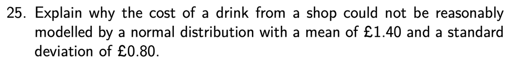

A common way of quickly considering what a normal distribution looks like is to imagine its *mean* in the centre and most of the curve lying within **2 standard deviations** from the mean.

Does this make sense in this context?

Negative values for the cost of a drink would lie within two standard deviations of the mean ($\text{1.40}-\text{2}\times\text{0.80}=-\text{0.20}$).

[figure not shown]

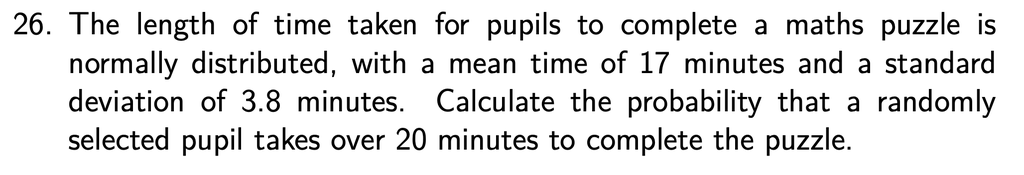

The $Z$ transformation for $X$ is:

$z=\dfrac{x-\mu}{\sigma}$

Remember the calculation functions $P()$ and $Q()$ for normal distributions.

$\text{P}(X>20)=\text{0.2148}$

[figure not shown]

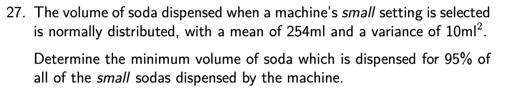

**DRAW A SKETCH**. Please.

A sketch with shaded probability and the data booklet leads to a $z$ value.

The $z$ transformation can then be applied.

248.8ml.

[figure not shown]

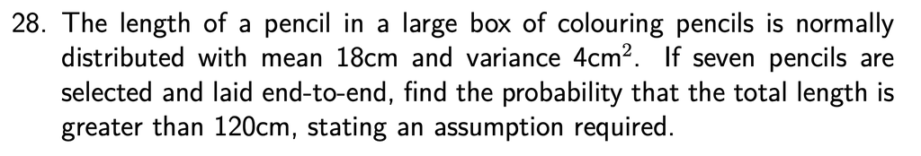

Questions involving *combining normal variables* often are worth 6-8 marks, so show your working clearly and don't rush it.

$\text{P}(X>120)=\text{0.8708}$

[figure not shown]

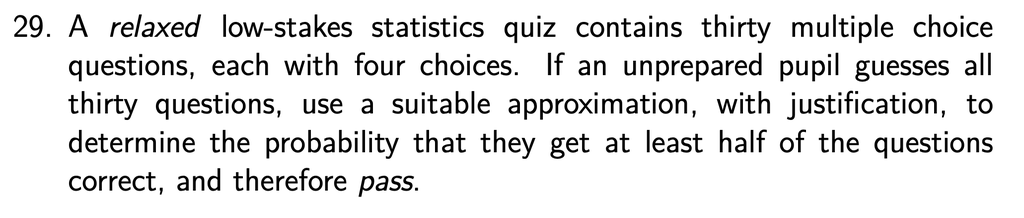

If it says **suitable approximation** then you **must** use the *normal approximation*.

You need to learn the specific conditions for a normal approximation to the Binomial, involving $np$ and $nq$.

The approximate ($\approx$) normal distribution should match the *mean and variance* of the original discrete distribution.

Since we are going from a *discrete* distribution to a *continuous* distribution, remember to use a...

$\text{P}(X\geqslant 15)=\text{0.0016}$

[figure not shown]

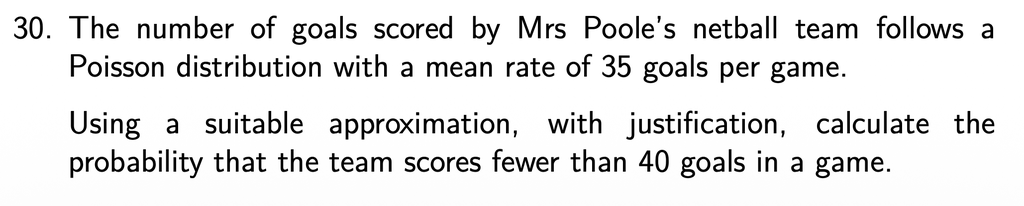

If it says **suitable approximation** then you **must** use the *normal approximation*.

You need to learn the specific conditions for a normal approximation to the Poisson involving $\lambda$.

The approximate ($\approx$) normal distribution should match the *mean and variance* of the original discrete distribution.

Since we are going from a *discrete* distribution to a *continuous* distribution, remember to use a...

$\text{P}(X< 40)=\text{0.7764}$

[figure not shown]